# Lesson 8 R Activity

Rick Davila

5/11/2020

## Lesson 8 - Install packages

#### Install necessary packages using library()

#### Perform data housekeeping - upload, name columns, display to make sure it reads properly, etc.

```r
knitr::opts_chunk$set(echo = TRUE)

library(e1071)
library(xtable)
library("xlsx") # Needed to read data
library(MASS) # Needed for ginv() function
library(nlme) # Needed for lme()


rm(list = ls())
```

## Example 5.5

#### Upload data-ex-PrintingInk.xlsx and label columns

```r
exL8 <- read.xlsx("data-ex-PrintingInk.xlsx",
                   sheetIndex = 1,
                   colIndex = c(1,2,3,4,5),
                   as.data.frame = TRUE,
                   header = TRUE)
```

#### Assign labels to data columns using names() and attach() commands

```r
names(exL8) <- c("x1","x2","x3","y_bar","s")
attach(exL8)
```

#### Output data to make sure it reads properly

```r
out <- as.data.frame(c(exL8))
colnames(out) <- c("x1","x2","x3","y_bar","s")
tab <- (xtable(out, digits=c(0,0,0,0,1,1)))
print(tab, type="html")
```

|  | x1 | x2 | x3 | y_bar | s |
| --- | --- | --- | --- | --- | --- |
| 1 | -1 | -1 | -1 | 24.0 | 12.5 |
| 2 | 0 | -1 | -1 | 120.3 | 8.4 |
| 3 | 1 | -1 | -1 | 213.7 | 42.8 |
| 4 | -1 | 0 | -1 | 86.0 | 3.7 |
| 5 | 0 | 0 | -1 | 136.7 | 80.4 |
| 6 | 1 | 0 | -1 | 340.7 | 16.2 |
| 7 | -1 | 1 | -1 | 112.3 | 27.6 |
| 8 | 0 | 1 | -1 | 256.3 | 4.6 |
| 9 | 1 | 1 | -1 | 271.7 | 23.6 |
| 10 | -1 | -1 | 0 | 81.0 | 0.0 |
| 11 | 0 | -1 | 0 | 101.7 | 17.7 |
| 12 | 1 | -1 | 0 | 357.0 | 32.9 |
| 13 | -1 | 0 | 0 | 171.3 | 15.0 |
| 14 | 0 | 0 | 0 | 372.0 | 0.0 |
| 15 | 1 | 0 | 0 | 501.7 | 92.5 |
| 16 | -1 | 1 | 0 | 264.0 | 63.5 |
| 17 | 0 | 1 | 0 | 427.0 | 88.6 |
| 18 | 1 | 1 | 0 | 730.7 | 21.1 |
| 19 | -1 | -1 | 1 | 220.7 | 133.8 |
| 20 | 0 | -1 | 1 | 239.7 | 23.5 |
| 21 | 1 | -1 | 1 | 422.0 | 18.5 |
| 22 | -1 | 0 | 1 | 199.0 | 29.4 |
| 23 | 0 | 0 | 1 | 485.3 | 44.6 |
| 24 | 1 | 0 | 1 | 673.7 | 158.2 |
| 25 | -1 | 1 | 1 | 176.7 | 55.5 |
| 26 | 0 | 1 | 1 | 501.0 | 138.9 |
| 27 | 1 | 1 | 1 | 1010.0 | 142.5 |

```r
# Output data structure and dimensions
str(exL8)
```

‘data.frame’: 27 obs. of 5 variables: $ x1 : num -1 0 1 -1 0 1 -1 0 1 -1 … $ x2 : num -1 -1 -1 0 0 0 1 1 1 -1 … $ x3 : num -1 -1 -1 -1 -1 -1 -1 -1 -1 0 … $ y_bar: num 24 120 214 86 137 … $ s : num 12.5 8.4 42.8 3.7 80.4 16.2 27.6 4.6 23.6 0 …

```r
dim(exL8)
```

[1] 27 5

#### Create a linear model relating the regressors to the standard deviation (‘s’ in th data file)

```r
model.1 <- lm(s ~ x1 + x2 + x3)
summary(model.1)
```

Call: lm(formula = s ~ x1 + x2 + x3)

Residuals: Min 1Q Median 3Q Max -54.87 -27.51 -11.29 26.53 83.47

Coefficients: Estimate Std. Error t value Pr(>|t|)  
(Intercept) 48.000 7.808 6.147 2.85e-06 * x1 11.517 9.563 1.204 0.24072  
x2 15.322 9.563 1.602 0.12275  
x3 29.172 9.563 3.051 0.00567 — Signif. codes: 0 ‘**’ 0.001 ’**’ 0.01 ’’ 0.05 ‘.’ 0.1 ’ ’ 1

Residual standard error: 40.57 on 23 degrees of freedom Multiple R-squared: 0.3668, Adjusted R-squared: 0.2842 F-statistic: 4.441 on 3 and 23 DF, p-value: 0.0133

```r
xtable(summary(model.1))
```

|  | Estimate | Std. Error | t value | Pr(>\|t\|) |
| --- | --- | --- | --- | --- |
| (Intercept) | 48.00000 | 7.808187 | 6.147394 | 2.853040e-06 |
| x1 | 11.51667 | 9.563037 | 1.204290 | 2.407249e-01 |
| x2 | 15.32222 | 9.563037 | 1.602234 | 1.227502e-01 |
| x3 | 29.17222 | 9.563037 | 3.050519 | 5.674023e-03 |

```r
xtable(anova(model.1))
```

|  | Df | Sum Sq | Mean Sq | F value | Pr(>F) |
| --- | --- | --- | --- | --- | --- |
| x1 | 1 | 2387.405 | 2387.405 | 1.450314 | 0.240724942 |
| x2 | 1 | 4225.869 | 4225.869 | 2.567154 | 0.122750231 |
| x3 | 1 | 15318.334 | 15318.334 | 9.305664 | 0.005674023 |
| Residuals | 23 | 37860.992 | 1646.130 | NA | NA |

#### Define model weights

```r
# fitted standard deviations based on x1, x2 and x3 regressors
y_hat.1 <- model.1$fitted.values    # fitted values
wts.1 <- 1/(y_hat.1^2 + 1)          # weights using recommend approach
V <- diag(1/wts.1)                  # diag matrix V
W <- ginv(V,
          tol=.Machine$double.eps)  # diag matrix W
```

#### Solve weighted least squares using matrices

```r
# Define X matrix of regressor observations
X <- cbind(matrix(1,length(x1),1),
           as.matrix(x1),
           as.matrix(x2),
           as.matrix(x3))
y <- as.matrix(y_bar)

# Calculate C Matrix -- defined tol to use higher precision
beta_matrix <- ginv(t(X) %*% W %*% X,
                    tol=.Machine$double.eps) %*% t(X) %*% W %*% y
```

#### Solve weighted least squares using lm() and entering weights

```r
# us weights determined in previous section

model.2 <- lm(y_bar ~ x1 + x2 + x3, weights = wts.1)
summary(model.2)
```

```
##
## Call:
## lm(formula = y_bar ~ x1 + x2 + x3, weights = wts.1)
##
## Weighted Residuals:
##     Min      1Q  Median      3Q     Max
## -3.6254 -1.2823  0.1667  1.3308  4.2558
##
## Coefficients:
##             Estimate Std. Error t value Pr(>|t|)
## (Intercept)   289.53      18.90  15.319 1.47e-13 ***
## x1            108.20      10.61  10.203 5.23e-10 ***
## x2             69.31      11.57   5.989 4.16e-06 ***
## x3            100.28      17.93   5.594 1.08e-05 ***
## ---
## Signif. codes:  0 '***' 0.001 '**' 0.01 '*' 0.05 '.' 0.1 ' ' 1
##
## Residual standard error: 1.954 on 23 degrees of freedom
## Multiple R-squared:  0.8671, Adjusted R-squared:  0.8498
## F-statistic: 50.02 on 3 and 23 DF,  p-value: 3.081e-10
```

```r
xtable(summary(model.2))
```

|  | Estimate | Std. Error | t value | Pr(>\|t\|) |
| --- | --- | --- | --- | --- |
| (Intercept) | 289.53470 | 18.90086 | 15.318596 | 1.471686e-13 |
| x1 | 108.20059 | 10.60503 | 10.202764 | 5.227332e-10 |
| x2 | 69.30814 | 11.57181 | 5.989394 | 4.161321e-06 |
| x3 | 100.28229 | 17.92827 | 5.593527 | 1.083511e-05 |

```r
xtable(anova(model.2))
```

|  | Df | Sum Sq | Mean Sq | F value | Pr(>F) |
| --- | --- | --- | --- | --- | --- |
| x1 | 1 | 270.08404 | 270.084037 | 70.76544 | 1.792084e-08 |
| x2 | 1 | 183.25088 | 183.250880 | 48.01405 | 4.600139e-07 |
| x3 | 1 | 119.41235 | 119.412349 | 31.28755 | 1.083511e-05 |
| Residuals | 23 | 87.78201 | 3.816609 | NA | NA |

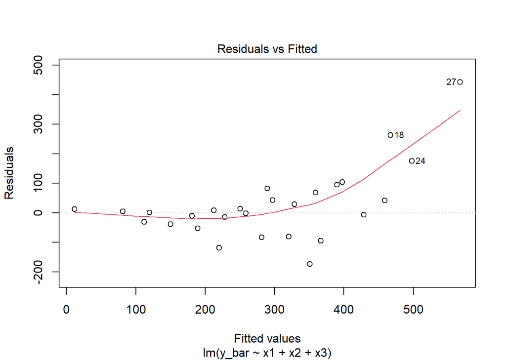

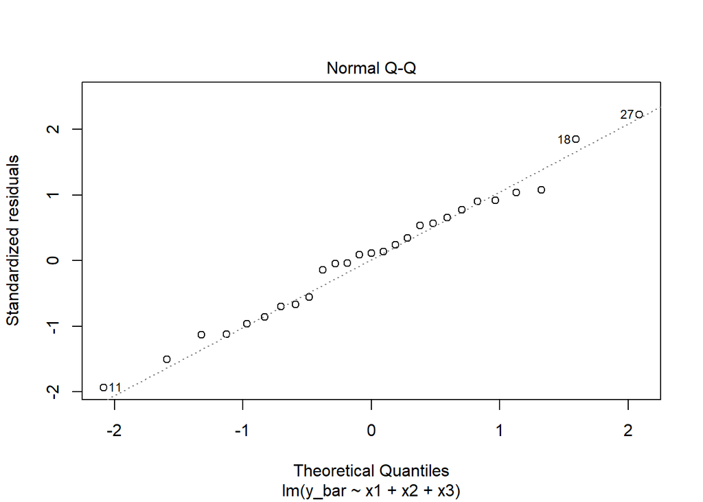

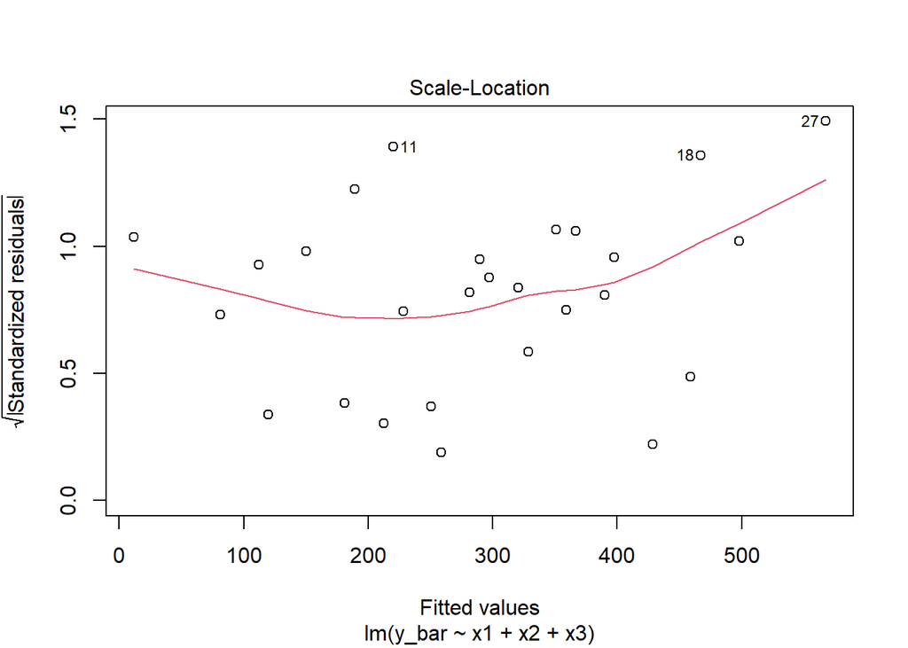

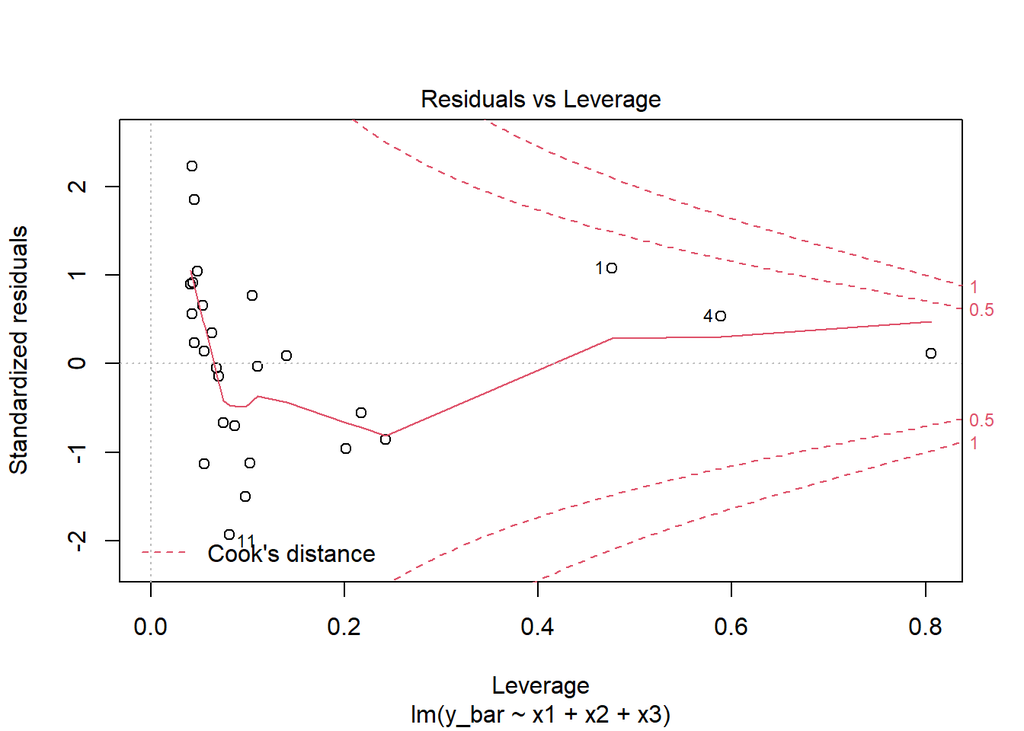

```r
plot(model.2)
```

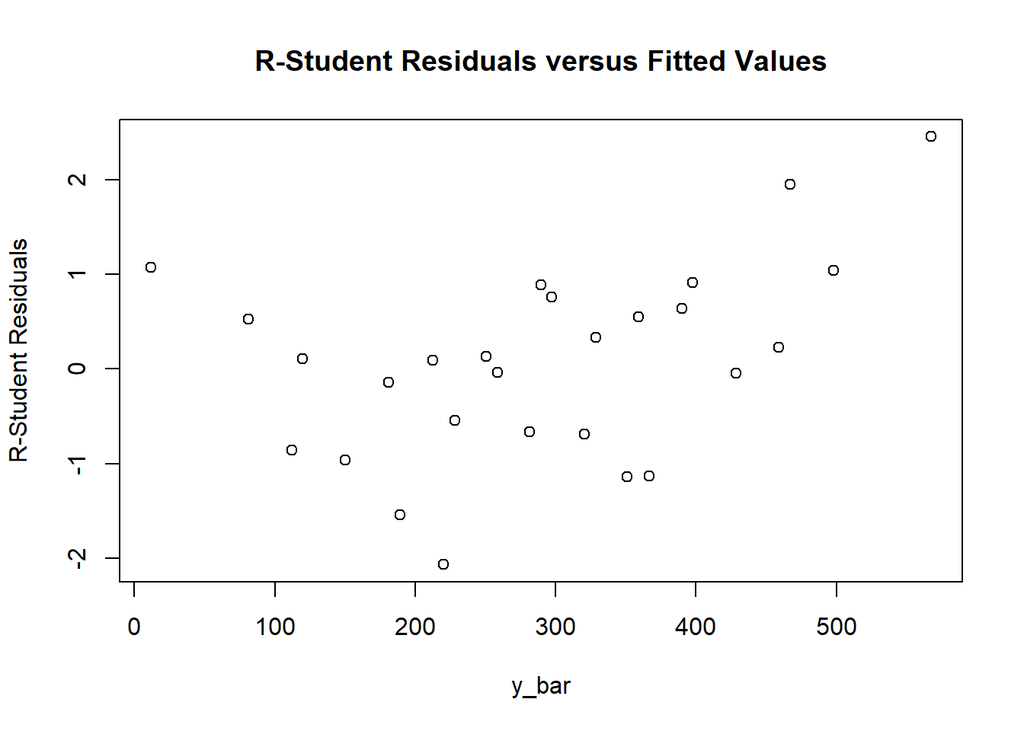

```r
# Calculate r_student residuals
R_Student_Residuals.2 <- rstudent(model.2)

y_hat.2 <- model.2$fitted.values

plot(y_hat.2, R_Student_Residuals.2, ylab = "R-Student Residuals", xlab = "y_bar", main = "R−Student Residuals versus Fitted Values")
```

#### Display both sets of coefficients - should be the same (minor differences possible due to rounding)

```r
model.1coeff <- as.data.frame(c(beta_matrix[1],
                                beta_matrix[2],
                                beta_matrix[3],
                                beta_matrix[4]))
model.2coeff <- as.data.frame(c(model.2$coefficients[1],
                                model.2$coefficients[2],
                                model.2$coefficients[3],
                                model.2$coefficients[4]))

out <- as.data.frame(c(model.1coeff, model.2coeff))
colnames(out) <- c("matrix",
                   "using lm()")
rownames(out) <- c("beta_0","beta_1","beta_2","beta_3")
tab <- (xtable(out, digits=c(0,6,6)))
print(tab, type="html")
```

|  | matrix | using lm() |
| --- | --- | --- |
| beta_0 | 289.534697 | 289.534697 |
| beta_1 | 108.200587 | 108.200587 |
| beta_2 | 69.308140 | 69.308140 |
| beta_3 | 100.282292 | 100.282292 |

## Example 5.6 (p. 196-199)

#### Upload data-ex-5-6.xlsx and label columns

```r
exL8_5pt6 <- read.xlsx("data-ex-5-6.xlsx",
                   sheetIndex = 1,
                   colIndex = c(1,2,3,4,5,6),
                   as.data.frame = TRUE,
                   header = TRUE)

names(exL8_5pt6) <- c("Helicopter",
                      "Aspect",
                      "Paper",
                      "Interaction",
                      "Rep",
                      "Time")
attach(exL8_5pt6)

out <- as.data.frame(c(exL8_5pt6))
colnames(out) <- c("Helicopter",
                      "Aspect",
                      "Paper",
                      "Interaction",
                      "Rep",
                      "Time")
tab <- (xtable(out, digits=c(0,0,0,0,0,0,2)))
print(tab, type="html")
```

|  | Helicopter | Aspect | Paper | Interaction | Rep | Time |
| --- | --- | --- | --- | --- | --- | --- |
| 1 | 1 | 1 | -1 | -1 | 1 | 3.60 |
| 2 | 1 | 1 | -1 | -1 | 1 | 3.85 |
| 3 | 1 | 1 | -1 | -1 | 1 | 3.98 |
| 4 | 2 | -1 | -1 | 1 | 1 | 6.44 |
| 5 | 2 | -1 | -1 | 1 | 1 | 6.37 |
| 6 | 2 | -1 | -1 | 1 | 1 | 6.78 |
| 7 | 3 | -1 | 1 | -1 | 1 | 6.84 |
| 8 | 3 | -1 | 1 | -1 | 1 | 6.90 |
| 9 | 3 | -1 | 1 | -1 | 1 | 7.18 |
| 10 | 4 | -1 | 1 | -1 | 2 | 6.37 |
| 11 | 4 | -1 | 1 | -1 | 2 | 6.38 |
| 12 | 4 | -1 | 1 | -1 | 2 | 6.58 |
| 13 | 5 | 1 | 1 | 1 | 1 | 3.44 |
| 14 | 5 | 1 | 1 | 1 | 1 | 3.43 |
| 15 | 5 | 1 | 1 | 1 | 1 | 3.75 |
| 16 | 6 | 1 | -1 | -1 | 2 | 3.75 |
| 17 | 6 | 1 | -1 | -1 | 2 | 3.73 |
| 18 | 6 | 1 | -1 | -1 | 2 | 4.10 |
| 19 | 7 | 1 | 1 | 1 | 2 | 4.59 |
| 20 | 7 | 1 | 1 | 1 | 2 | 4.64 |
| 21 | 7 | 1 | 1 | 1 | 2 | 5.02 |
| 22 | 8 | -1 | -1 | 1 | 2 | 6.50 |
| 23 | 8 | -1 | -1 | 1 | 2 | 6.33 |
| 24 | 8 | -1 | -1 | 1 | 2 | 6.92 |

```r
# Output data structure and dimensions
str(exL8_5pt6)
```

‘data.frame’: 24 obs. of 6 variables: $ Helicopter : num 1 1 1 2 2 2 3 3 3 4 … $ Aspect : num 1 1 1 -1 -1 -1 -1 -1 -1 -1 … $ Paper : num -1 -1 -1 -1 -1 -1 1 1 1 1 … $ Interaction: num -1 -1 -1 1 1 1 -1 -1 -1 -1 … $ Rep : num 1 1 1 1 1 1 1 1 1 2 … $ Time : num 3.6 3.85 3.98 6.44 6.37 6.78 6.84 6.9 7.18 6.37 …

```r
dim(exL8_5pt6)
```

[1] 24 6

#### Create a linear model predicting time as a function of aspect, paper,and the interaction. Results should match Table 5.11.

```r
model.3 <- lm(Time ~ Aspect + Paper + Interaction)
summary(model.3)
```

```
##
## Call:
## lm(formula = Time ~ Aspect + Paper + Interaction)
##
## Residuals:
##      Min       1Q   Median       3Q      Max
## -0.71500 -0.22875 -0.07083  0.23375  0.87500
##
## Coefficients:
##             Estimate Std. Error t value Pr(>|t|)
## (Intercept)  5.31125    0.08339  63.689  < 2e-16 ***
## Aspect      -1.32125    0.08339 -15.844 8.74e-13 ***
## Paper        0.11542    0.08339   1.384    0.182
## Interaction  0.03958    0.08339   0.475    0.640
## ---
## Signif. codes:  0 '***' 0.001 '**' 0.01 '*' 0.05 '.' 0.1 ' ' 1
##
## Residual standard error: 0.4085 on 20 degrees of freedom
## Multiple R-squared:  0.9268, Adjusted R-squared:  0.9158
## F-statistic: 84.39 on 3 and 20 DF,  p-value: 1.583e-11
```

```r
xtable(summary(model.3))
```

|  | Estimate | Std. Error | t value | Pr(>\|t\|) |
| --- | --- | --- | --- | --- |
| (Intercept) | 5.31125000 | 0.0833931 | 63.6893193 | 1.427502e-24 |
| Aspect | -1.32125000 | 0.0833931 | -15.8436363 | 8.736922e-13 |
| Paper | 0.11541667 | 0.0833931 | 1.3840073 | 1.816076e-01 |
| Interaction | 0.03958333 | 0.0833931 | 0.4746596 | 6.401715e-01 |

```r
xtable(anova(model.3))
```

|  | Df | Sum Sq | Mean Sq | F value | Pr(>F) |
| --- | --- | --- | --- | --- | --- |
| Aspect | 1 | 41.89683750 | 41.89683750 | 251.0208101 | 8.736922e-13 |
| Paper | 1 | 0.31970417 | 0.31970417 | 1.9154763 | 1.816076e-01 |
| Interaction | 1 | 0.03760417 | 0.03760417 | 0.2253017 | 6.401715e-01 |
| Residuals | 20 | 3.33811667 | 0.16690583 | NA | NA |

#### Create a linear model of groups, with the response being the group average (i.e. use Table 5.14 as input data). Results should match Table 5.15. Okay to manually input the Table 5.14 information.

```r
Helicopter <- c(1,2,3,4,5,6,7,8)
Aspect <- c(1,-1,-1,-1,1,1,1,-1)
Paper <- c(-1,-1,1,1,1,-1,1,-1)
Interaction <- c(-1,1,-1,-1,1,-1,1,1)
Time <- c(3.81, 6.53, 6.973, 6.443, 3.54, 3.86, 4.75, 6.583)

model.4 <- lm(Time ~ Aspect + Paper + Aspect*Paper)
summary(model.4)
```

```
##
## Call:
## lm(formula = Time ~ Aspect + Paper + Aspect * Paper)
##
## Residuals:
##       1       2       3       4       5       6       7       8
## -0.0250 -0.0265  0.2650 -0.2650 -0.6050  0.0250  0.6050  0.0265
##
## Coefficients:
##              Estimate Std. Error t value Pr(>|t|)
## (Intercept)   5.31112    0.16537  32.116  5.6e-06 ***
## Aspect       -1.32113    0.16537  -7.989  0.00133 **
## Paper         0.11537    0.16537   0.698  0.52382
## Aspect:Paper  0.03963    0.16537   0.240  0.82241
## ---
## Signif. codes:  0 '***' 0.001 '**' 0.01 '*' 0.05 '.' 0.1 ' ' 1
##
## Residual standard error: 0.4677 on 4 degrees of freedom
## Multiple R-squared:  0.9415, Adjusted R-squared:  0.8976
## F-statistic: 21.45 on 3 and 4 DF,  p-value: 0.006292
```

```r
xtable(summary(model.4))
```

|  | Estimate | Std. Error | t value | Pr(>\|t\|) |
| --- | --- | --- | --- | --- |
| (Intercept) | 5.311125 | 0.1653741 | 32.1158297 | 5.603673e-06 |
| Aspect | -1.321125 | 0.1653741 | -7.9887078 | 1.331028e-03 |
| Paper | 0.115375 | 0.1653741 | 0.6976608 | 5.238156e-01 |
| Aspect:Paper | 0.039625 | 0.1653741 | 0.2396083 | 8.224113e-01 |

```r
xtable(anova(model.4))
```

|  | Df | Sum Sq | Mean Sq | F value | Pr(>F) |
| --- | --- | --- | --- | --- | --- |
| Aspect | 1 | 13.96297013 | 13.96297013 | 63.81945188 | 0.001331028 |
| Paper | 1 | 0.10649112 | 0.10649112 | 0.48673063 | 0.523815552 |
| Aspect:Paper | 1 | 0.01256113 | 0.01256113 | 0.05741215 | 0.822411297 |
| Residuals | 4 | 0.87515450 | 0.21878863 | NA | NA |

## Example 5.7 (p.201-202)

#### Upload data-ex-5-7.xlsx and label columns

```r
exL8_5pt7 <- read.xlsx("data-ex-5-7.xlsx",
                   sheetIndex = 1,
                   colIndex = c(2,3,4,5),
                   as.data.frame = TRUE,
                   header = TRUE)

names(exL8_5pt7) <- c("time",
                      "cases",
                      "distance",
                      "city")
attach(exL8_5pt7)

out <- as.data.frame(c(exL8_5pt7))
colnames(out) <- c("time",
                   "cases",
                   "distance",
                   "city")
tab <- (xtable(out, digits=c(0,2,0,0,0)))
print(tab, type="html")
```

|  | time | cases | distance | city |
| --- | --- | --- | --- | --- |
| 1 | 16.68 | 7 | 560 | San Diego |
| 2 | 11.50 | 3 | 220 | San Diego |
| 3 | 12.03 | 3 | 340 | San Diego |
| 4 | 14.88 | 4 | 80 | San Diego |
| 5 | 13.75 | 6 | 150 | San Diego |
| 6 | 18.11 | 7 | 330 | San Diego |
| 7 | 8.00 | 2 | 110 | San Diego |
| 8 | 17.83 | 7 | 210 | Boston |
| 9 | 79.24 | 30 | 1460 | Boston |
| 10 | 21.50 | 5 | 605 | Boston |
| 11 | 40.33 | 16 | 688 | Boston |
| 12 | 21.00 | 10 | 215 | Boston |
| 13 | 13.50 | 4 | 255 | Boston |
| 14 | 19.75 | 6 | 462 | Boston |
| 15 | 24.00 | 9 | 448 | Boston |
| 16 | 29.00 | 10 | 776 | Boston |
| 17 | 15.35 | 6 | 200 | Boston |
| 18 | 19.00 | 7 | 132 | Austin |
| 19 | 9.50 | 3 | 36 | Austin |
| 20 | 35.10 | 17 | 770 | Austin |
| 21 | 17.90 | 10 | 140 | Austin |
| 22 | 52.32 | 26 | 810 | Austin |
| 23 | 18.75 | 9 | 450 | Austin |
| 24 | 19.83 | 8 | 635 | Minneapolis |
| 25 | 10.75 | 4 | 150 | Minneapolis |

```r
# Output data structure and dimensions
str(exL8_5pt7)
```

‘data.frame’: 25 obs. of 4 variables: $ time : num 16.7 11.5 12 14.9 13.8 … $ cases : num 7 3 3 4 6 7 2 7 30 5 … $ distance: num 560 220 340 80 150 330 110 210 1460 605 … $ city : chr “San Diego” “San Diego” “San Diego” “San Diego” …

```r
dim(exL8_5pt7)
```

[1] 25 4

#### Run regression model using City as a random factor using lme(). Compare StdDev for (Intercept) and Residual to variances in Figure 5.12.

```r
model.5 <- lme(time ~ cases + distance, random =~1|city)

summary(model.5)
```

```
## Linear mixed-effects model fit by REML
##   Data: NULL
##       AIC      BIC    logLik
##   146.684 152.1392 -68.34199
##
## Random effects:
##  Formula: ~1 | city
##         (Intercept) Residual
## StdDev:    1.609268 2.964796
##
## Fixed effects:  time ~ cases + distance
##                 Value Std.Error DF  t-value p-value
## (Intercept) 2.0754319 1.3204411 19 1.571772  0.1325
## cases       1.7148234 0.1719497 19 9.972817  0.0000
## distance    0.0120317 0.0035580 19 3.381543  0.0031
##  Correlation:
##          (Intr) cases
## cases    -0.213
## distance -0.143 -0.836
##
## Standardized Within-Group Residuals:
##         Min          Q1         Med          Q3         Max
## -1.52550355 -0.60242771 -0.09382676  0.34986657  2.24343282
##
## Number of Observations: 25
## Number of Groups: 4
```

```r
xtable(anova(model.5))
```

|  | numDF | denDF | F-value | p-value |
| --- | --- | --- | --- | --- |
| (Intercept) | 1 | 19 | 430.78289 | 1.620926e-14 |
| cases | 1 | 19 | 545.54731 | 1.887379e-15 |
| distance | 1 | 19 | 11.43483 | 3.132507e-03 |

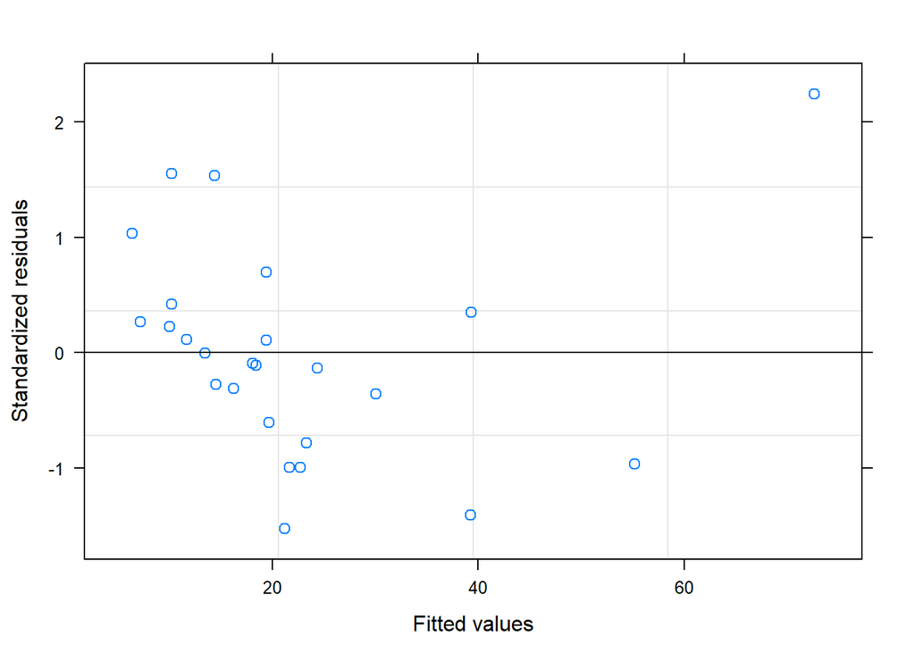

```r
plot(model.5)
```

```r
sd_res <- model.5$sigma
var_res <- sd_res^2
```

From lme(), the standard deviation for the residual is $2.9647961$, which, when squared is equal to the variance in Figure 5.12 in the book, $8.7900161$.

Similarly, for the Intercept, the standard deviation is $1.609268$, and the variance is $2.589743$, matching the value in Figure 5.12.